# ColorDetection

### Importing the modules

```python
import cv2
import numpy as np
import matplotlib.pyplot as plt
from glob import glob
```

### Reading the files

```python
files = glob("Dataset/Filtered/*")
```

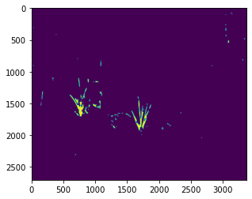

```python
img = cv2.imread("Dataset/Filtered/PGR_2022-06-14-165706.bmp")
hsv = cv2.cvtColor(img, cv2.COLOR_BGR2HSV)
# lower bound and upper bound for Green color
lower_bound = np.array([30,80,20])
upper_bound = np.array([90, 255, 255])
# find the colors within the boundaries
mask = cv2.inRange(hsv, lower_bound, upper_bound)
#ims = cv2.resize(mask, (900, 700))
#define kernel size
kernel = np.ones((7,7),np.uint8)
mask = cv2.morphologyEx(mask, cv2.MORPH_CLOSE, kernel)
mask = cv2.morphologyEx(mask, cv2.MORPH_OPEN, kernel)
plt.imshow(mask)
```

### Calculating the area of grass in each image

```python
areas=[]
for file in files:
    img = cv2.imread(file)
    hsv = cv2.cvtColor(img, cv2.COLOR_BGR2HSV)
    # lower bound and upper bound for Green color
    lower_bound = np.array([30,80,20])
    upper_bound = np.array([90, 255, 255])
    # find the colors within the boundaries
    mask = cv2.inRange(hsv, lower_bound, upper_bound)
    ims = cv2.resize(mask, (900, 700))
    #define kernel size
    kernel = np.ones((7,7),np.uint8)
    mask = cv2.morphologyEx(mask, cv2.MORPH_CLOSE, kernel)
    mask = cv2.morphologyEx(mask, cv2.MORPH_OPEN, kernel)
    contours, hierarchy = cv2.findContours(mask.copy(), cv2.RETR_EXTERNAL, cv2.CHAIN_APPROX_SIMPLE)
    area=0
    for cnt in contours:
        area+=cv2.contourArea(cnt)
    areas.append(int(area))
    #print(i,area)
```

Working: After color detection, all the contours in the image has been identified and its area has been calculated using the `cv2.contourArea` function. For each image the total area of grass present in the image is calculated.

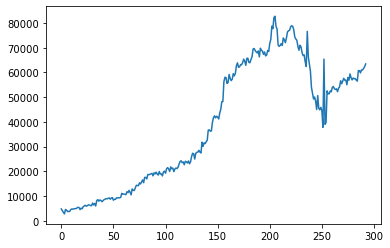

```python
plt.plot(areas)
plt.show()
```

Inference: Since the images has been ordered based on the days we could very well use them to see the gradual change in the area. Until the first 200 images there has been an gradual increase in the area signifying the growth of the grass. However after 200 there has been an significant drop in the growth of the image.

Possible reasons:

- Quality of the image is poor
- The grass behind the region of interest hindered the area calculation
- The grass started to deteriorate

### Manual Segmentation

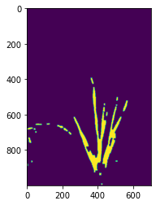

```python
plt.imshow(mask[1000:2000,1300:2000])
```

Segmenting the area of one grass plant to analyse the discrepancy in the growth of the plant.

### Calculating the growth of one grass plant

```python
areas=[]
for file in files:
    img = cv2.imread(file)
    hsv = cv2.cvtColor(img, cv2.COLOR_BGR2HSV)
    # lower bound and upper bound for Green color
    lower_bound = np.array([30,80,20])
    upper_bound = np.array([90, 255, 255])
    # find the colors within the boundaries
    mask = cv2.inRange(hsv, lower_bound, upper_bound)
    ims = cv2.resize(mask, (900, 700))
    #define kernel size
    kernel = np.ones((7,7),np.uint8)
    mask = cv2.morphologyEx(mask, cv2.MORPH_CLOSE, kernel)
    mask = cv2.morphologyEx(mask, cv2.MORPH_OPEN, kernel)
    contours, hierarchy = cv2.findContours(mask[1000:2000,1300:2000], cv2.RETR_EXTERNAL, cv2.CHAIN_APPROX_SIMPLE)
    area=0
    for cnt in contours:
        area+=cv2.contourArea(cnt)
    areas.append(int(area))
    #print(i,area)
```

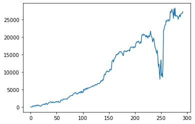

```python
plt.plot(areas)
plt.show()
```

We could actually get a good picture on the growth of the plant. If there is a logic explanation from Dr.Kavitha on why the plant deteriorated then we are good to go.